# Assignment 10: Predictive Modeling - Part 1

*How to do it?*:

- Open the Rmarkdown file of this assignment (link) in Rstudio.
- Right under each **question**, insert a code chunk (you can use the hotkey `Ctrl + Alt + I` to add a code chunk) and code the solution for the question.
- `Knit` the rmarkdown file (hotkey: `Ctrl + Alt + K`) to export an html.
- Publish the html file to your Githiub Page.

*Submission*: Submit the link on Github of the assignment to Canvas

1. Use the `Adult Census Income` dataset. We will predict the income (whether or not it is more than 50k or not) of an adult. Import the dataset. Partition the data into 80% training and 20% testing.

```r
# install.packages("caret")
# install.packages("rattle")

# Calling libraries
library(tidyverse)
library(caret)
library(rpart)
library(rattle)
library(randomForest)

# Reading in data
df = read_csv("adult_census.csv")

# Removing columns
df <- df %>% select(-fnlwgt, -education.num)

# Renaming target column
df <- df %>% rename(target=income)

# Making sure all categorical variables are factors
df <- df %>%
  mutate(target = as.factor(target),
         workclass = as.factor(workclass),
         education = as.factor(education),
         marital.status = as.factor(marital.status),
         occupation = as.factor(occupation),
         relationship = as.factor(relationship),
         race = as.factor(race),
         sex = as.factor(sex),
         native.country = as.factor(native.country))

# Checking for NAs
sum(is.na(df))
```

```
## [1] 0
```

```r
# There are 0 NAs, however there are '?'s present in the variables below (ran table function to check other categorical variables)

# Replacing the '?'s with NA
df$workclass <- na_if(df$workclass, '?')
df$occupation <- na_if(df$occupation, '?')
df$native.country <- na_if(df$native.country, '?')

# Dropping rows with NAs
df = drop_na(df)

# Splitting data
set.seed(2020)
splitIndex <- createDataPartition(df$target, p = 0.80, list = FALSE)
df_train <- df[ splitIndex,]
df_test <- df[ -splitIndex,]
```

2. Practice Decision Tree. Do the follows:
- Use `rpart` package, create a decision tree with maximum depth of 3.
- Calculate the accuracy of the model on the testing data. Notice that the positive outcome here is not `1` but `>50K` or `<50K`.
- Plot the tree
- Plot the variable importance by the tree

```r
# Creating a decision tree with max depth of 3
tree_1 <- rpart(target ~ ., data = df_train,
                 control = rpart.control(maxdepth = 3))

# Calculating the accuracy of the model on the testing data
pred_1 <- predict(tree_1, df_test, type = "class")

cm_1 <- confusionMatrix(data = pred_1, reference = df_test$target)
cm_1$overall[1]
```

```
##  Accuracy
## 0.8434754
```

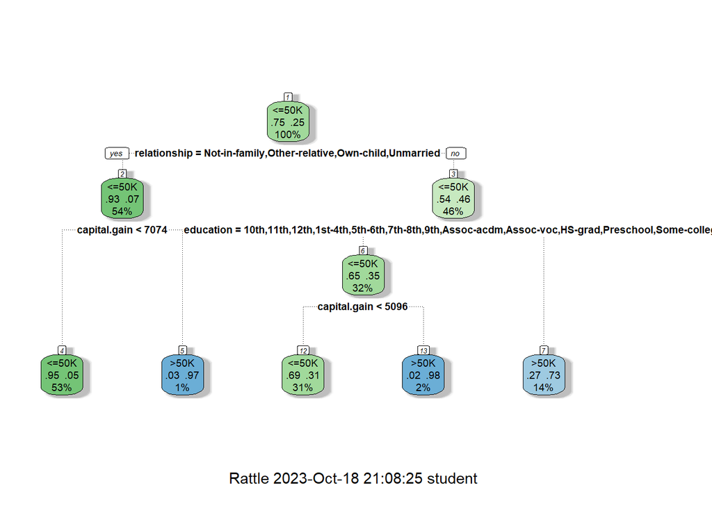

```r
# Plotting the tree
fancyRpartPlot(tree_1)
```

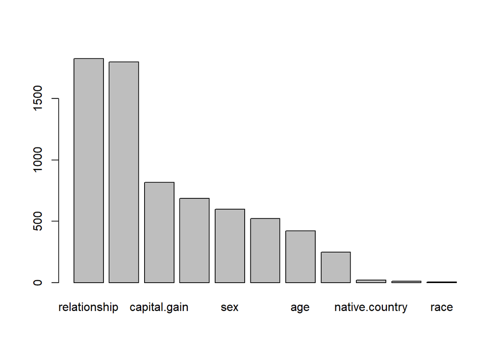

```r
# Plotting the variable importance by the tree
barplot(tree_1$variable.importance)
```

3. Create 3 more trees and compare the testing accuracy of these trees, which tree give the highest testing accuracy.

```r
# Creating a decision tree with max depth of 2
tree_2 <- rpart(target ~ ., data = df_train,
                 control = rpart.control(maxdepth = 2))

# Calculating the accuracy of the model on the testing data
pred_2 <- predict(tree_2, df_test, type = "class")

cm_2 <- confusionMatrix(data = pred_2, reference = df_test$target)
cm_2$overall[1]
```

```
##  Accuracy
## 0.8287183
```

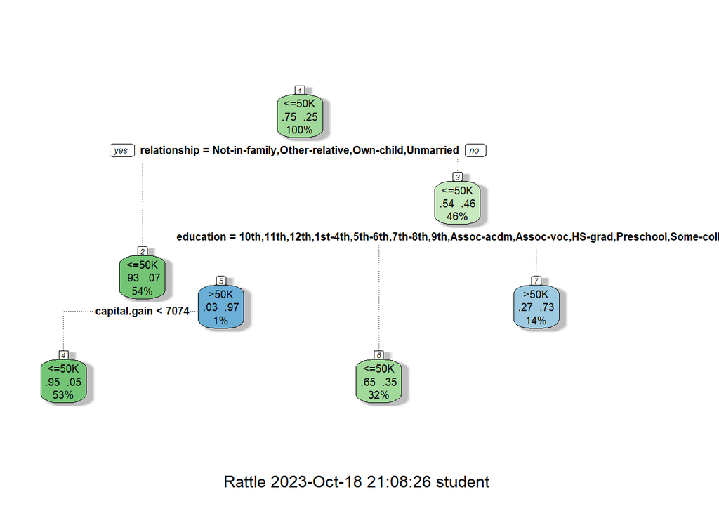

```r
# Plotting the tree
fancyRpartPlot(tree_2)
```

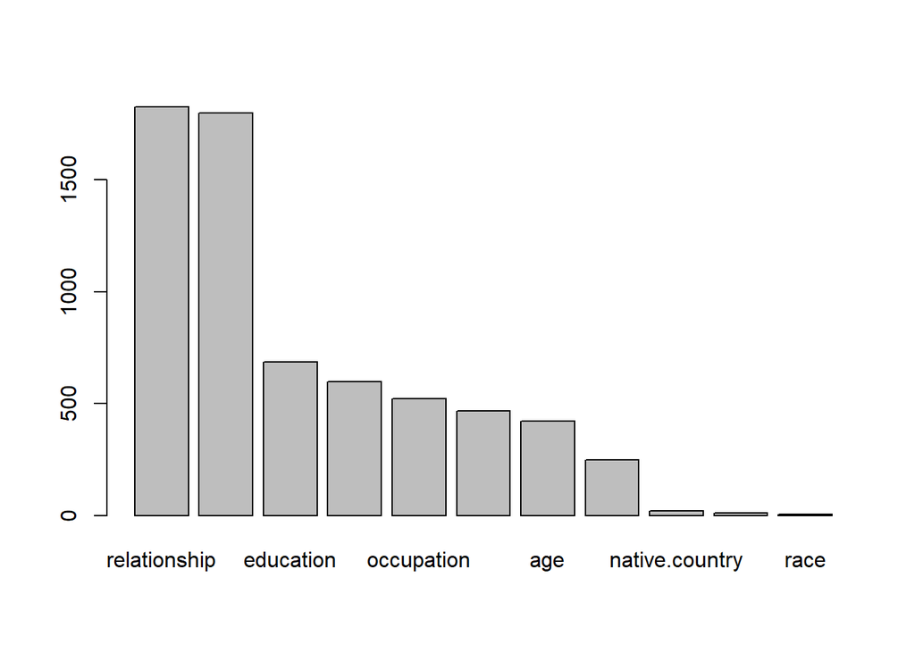

```r
# Plotting the variable importance by the tree
barplot(tree_2$variable.importance)
```

```r
# Creating a decision tree with max depth of 3 and a complexity parameter of 0.10 (vs default value of 0.01)
tree_3 <- rpart(target ~ ., data = df_train,
                 control = rpart.control(maxdepth = 3, cp = 0.10))

# Calculating the accuracy of the model on the testing data
pred_3 <- predict(tree_3, df_test, type = "class")

cm_3 <- confusionMatrix(data = pred_3, reference = df_test$target)
cm_3$overall[1]
```

```
##  Accuracy
## 0.8229149
```

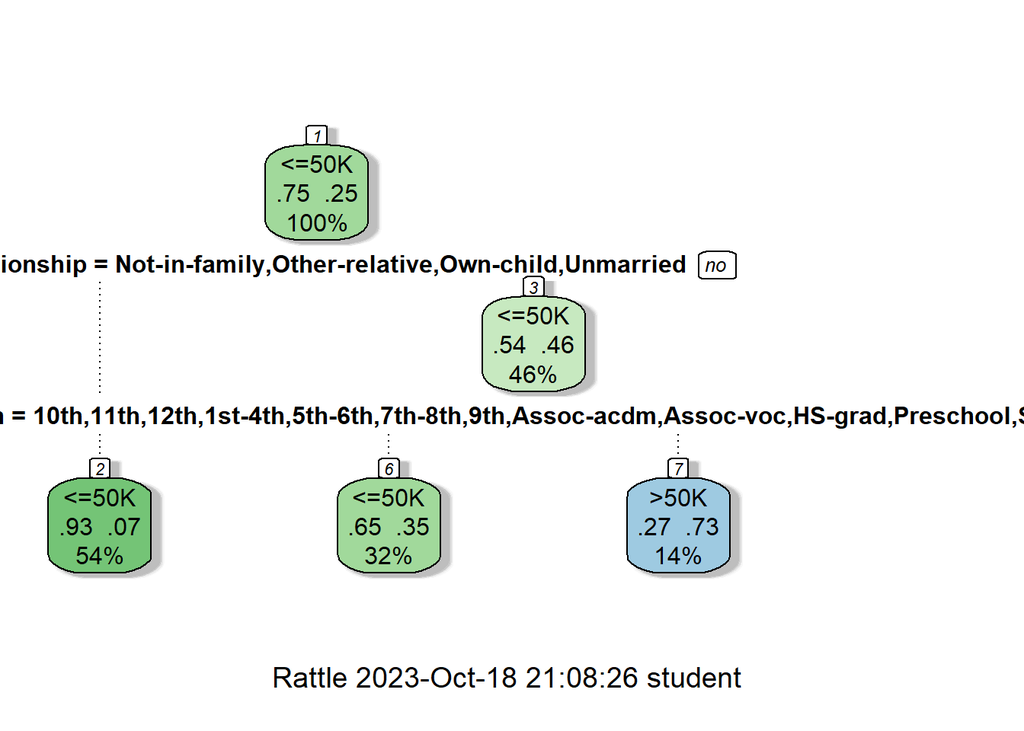

```r
# Plotting the tree
fancyRpartPlot(tree_3)
```

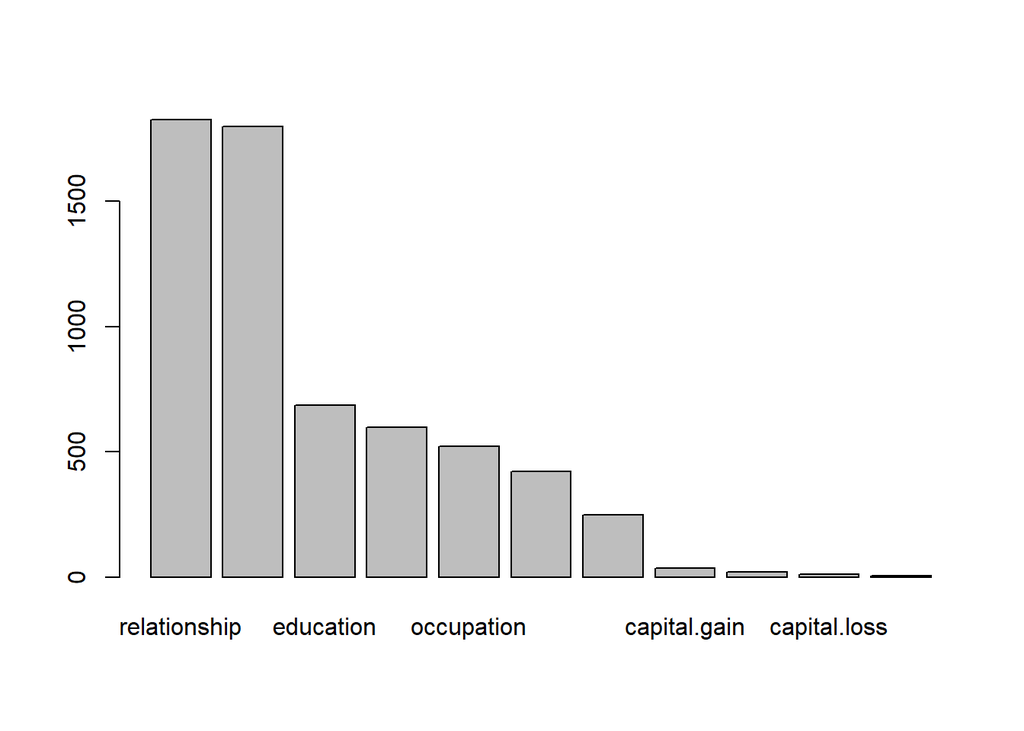

```r
# Plotting the variable importance by the tree
barplot(tree_3$variable.importance)
```

```r
# Creating a decision tree with max depth of 2 and a complexity parameter of 0.10 (vs default of 0.01)
tree_4 <- rpart(target ~ ., data = df_train,
                 control = rpart.control(maxdepth = 2, cp = 0.10))

# Calculating the accuracy of the model on the testing data
pred_4 <- predict(tree_4, df_test, type = "class")

cm_4 <- confusionMatrix(data = pred_4, reference = df_test$target)
cm_4$overall[1]
```

```
##  Accuracy
## 0.8229149
```